# Computerphile Data Analysis Series

# 0. Introduction to Data Analysis

- Data Analysis
- Big Data
- Machine Learning
- Artificial Intelligence
- Clustering
- Data Mining
- Data Pre-processing

If we need to extract value from data, we need a formal set of tools to avail of the information within it, this is data science.

Machine Learning is a subset of AI, the fact that you train a machine to do something from data, so you train it up from nothing using examples from data. AI is often rule based, and the agent doesn’t learn.

Data frames are like tables in excel, except you’ve also got headings for columns unlike excel.

```r
airlineData <- airmiles
studentData <- as.data.frame(HairEyeColor)
par(mfrow = c(1,2))
print(studentData$Hair)
```

```
 [1] Black Brown Red   Blond Black Brown Red   Blond Black Brown Red   Blond Black Brown
[15] Red   Blond Black Brown Red   Blond Black Brown Red   Blond Black Brown Red   Blond
[29] Black Brown Red   Blond
Levels: Black Brown Red Blond
```

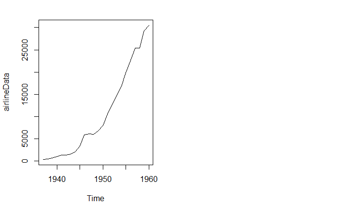

```r
plot(airlineData)
```

- Data Analysis: Using statistical analysis to figure out what’s going on
- Data Visualisation: Plotting and chart to figure out what is going on
- Pre-process: Weed out the data to drill down to what is the most important parts of information
- Data Modelling: Predicting from the data what is going to happen e.g. Looking at products online and predict what you want to buy
- Data Mining: Extract Data from a given source
- Big Data: When we collect a hige number of examples, and/or each of our examples has a very large amount of variables. It is typically data that we can’t feasibly run on our laptops

# 1. What is data

- Data has to be measurable

### Four types of data

- **N**ominal: E.g. colours. No measurable distance between colours. Is red closer to blue or green? Can’t use average, only mode, no order.
- **O**rdered: E.g. film star rating systems. Ordered, but no real measurable distance between stars.
- **I**nterval: E.g. Temperature. 0 degrees isn’t no temperature, it is still a temperature. Can use range, mode. Does 10 degrees feel twice as hot as 5? No. There is still a lack of scale.
- **R**atio: E.g. Number Children. 0 children means no children. 4 children is double 2 children

Dataframe could be made up of a combination of these types of data.

### Excel vs R

- No rule based implementation in excel
- R or Python has a set of rules to execute on the data in a given order, which is much better for recording your research, your steps, your methodology and order of implementation

```r
tennis = read.csv("tennis.csv")
head(tennis)
```

|  | ï..Day | Outlook | Temperature | Humidity | Wind..kmh. | Play |
| --- | --- | --- | --- | --- | --- | --- |
| 1 | 1 | sunny | 20 | high | 9 | no |
| 2 | 2 | sunny | 18 | high | 4 | no |
| 3 | 3 | overcast | 5 | high | 0 | yes |
| 4 | 4 | rainy | 8 | high | 10 | yes |
| 5 | 5 | rainy | 10 | normal | 12 | yes |
| 6 | 6 | rainy | 13 | normal | 5 | no |

In the tennis data here, we could use machine learning of each of the variables to predict whether they play or not. * Nominial: Outlook * Ordinal: Humidity * Interval: Temperature * Ratio: Wind